# MEH BOT: Maximizing Emotional Help By Organizing Text 🤖

By: Rohan Mathur, Ritik Chopra, Arnav Mittal

## Purpose ⭐

Mental health is an often overlooked portion of our daily lives and as such a major goal of this project is to provide aid to one’s own mental strife as a consequence of daily general inconveniences.

Inspirational quotes have been a part of our culture for a long time. We can find examples of this in t-shirts, decorations, as well as online images.

Giving (at least a little) happiness through the form of tailored inspirational quotes could go a long way.

We wanted to create a bot that has the capability of generating text that would help other people feel better. Our goal was to provide a way to receive emotional relief through the use of this bot (or at least a starting framework to do so). Everyone has problems, we were hoping to provide an aid to those problems.

## Generating Helpful Quotes 🪔

In this model, we are using the Inspirational Quotes dataset, https://www.kaggle.com/datasets/mattimansha/inspirational-quotes in order to generate new phrases that would be comparable to a quote that has already been said. The idea is to take the queries that have been provided and relate them to already existing inspirational quotes. That way we can hope to produce a response that can give comfort to a user.

## Import the libraries 📚

As the first step, we need to import the required libraries:

We make use of several tensorflow libraries that will be discussed later. It should be noted that we are using tensorflow’s sequential model for the processing of our data. Considering that we are processing a sequence of sentences, the need to understand previous sentiments of the sentence requires the use of a sequential model.

```python
# Tensorflow module for building generative model
import tensorflow as tf
from tensorflow.keras.utils import pad_sequences
from tensorflow.keras.layers import Embedding, LSTM, Dense, Dropout
from tensorflow.keras.preprocessing.text import Tokenizer
from tensorflow.keras.callbacks import EarlyStopping
from tensorflow.keras.models import Sequential
import tensorflow.keras.utils as ku

import pandas as pd
import numpy as np
import string, os

import warnings
warnings.filterwarnings("ignore")
warnings.simplefilter(action='ignore', category=FutureWarning)
```

## Load the dataset 📋

In this section we are going to load the dataset of Categories and Quotes.

Since our dataset is in the form of a csv file, we can use the Pandas library to convert the CSV into a dataframe. We then isolated the columns that we wanted which were the "Category" and "Quote" column. We can then concatenate the two columns together by separating them with a colon and creating a new column in our dataset. We then converted our new column into a list.

```python
data = pd.read_csv("./inspiration.csv", index_col = 0)
data["all_text"] = data["Category"].astype(str) +":"+ data["Quote"]
new_data = data["all_text"]
quotes = new_data.tolist()
data
```

|  | Category | Quote | Image-link | Quote-url | all_text |
| --- | --- | --- | --- | --- | --- |
| 0 | LOVE | Let us see what love can do. | https://assets.passiton.com/quotes/quote_artwo... | /inspirational-quotes/6900-let-us-see-what-lov... | LOVE:Let us see what love can do. |
| 1 | LOVE | We can’t heal the world today. But we can begi... | https://assets.passiton.com/quotes/quote_artwo... | /inspirational-quotes/8169-we-can-t-heal-the-w... | LOVE:We can’t heal the world today. But we can... |
| 2 | LISTENING | Listen with curiosity. Speak with honesty. Act... | https://assets.passiton.com/quotes/quote_artwo... | /inspirational-quotes/8083-listen-with-curiosi... | LISTENING:Listen with curiosity. Speak with ho... |
| 3 | LISTENING | The most basic and powerful way to connect to ... | https://assets.passiton.com/quotes/quote_artwo... | /inspirational-quotes/7139-the-most-basic-and-... | LISTENING:The most basic and powerful way to c... |
| 4 | LISTENING | Knowledge speaks, but wisdom listens. | https://assets.passiton.com/quotes/quote_artwo... | /inspirational-quotes/8376-knowledge-speaks-bu... | LISTENING:Knowledge speaks, but wisdom listens. |
| ... | ... | ... | ... | ... | ... |
| 1741 | COURAGE | I was set free because my greatest fear had be... | https://assets.passiton.com/quotes/quote_artwo... | /inspirational-quotes/7022-i-was-set-free-beca... | COURAGE:I was set free because my greatest fea... |
| 1742 | COURAGE | Comedy is defiance. It's a snort of contempt i... | https://assets.passiton.com/quotes/quote_artwo... | /inspirational-quotes/7021-comedy-is-defiance-... | COURAGE:Comedy is defiance. It's a snort of co... |
| 1743 | PURPOSE | Every piece of the universe, even the tiniest ... | https://assets.passiton.com/quotes/quote_artwo... | /inspirational-quotes/6908-every-piece-of-the-... | PURPOSE:Every piece of the universe, even the ... |
| 1744 | JUSTICE | Take a stand for what's right. Raise a ruckus ... | https://assets.passiton.com/quotes/quote_artwo... | /inspirational-quotes/6781-take-a-stand-for-wh... | JUSTICE:Take a stand for what's right. Raise a... |
| 1745 | LOVE | There's something about love that people just ... | https://assets.passiton.com/quotes/quote_artwo... | /inspirational-quotes/6380-theres-something-ab... | LOVE:There's something about love that people ... |

1746 rows × 5 columns

# Analyzing the dataset 📊

Creating a distribution of the occurence of each category.

We can see that there is a non-uniform distribution of the number of quotes per category. This indicates that our predictions may be biased towards the examples with categories of a higher amount of quotes.

(Unimplemented): To possibly resolve this, we can generate more quotes for the categories with lower amount of quotes and make a uniform distribution with a higher example count or reduce the number of examples from the higher category counts on a random basis to create a uniform distibution with a lower example count.

```
<function matplotlib.pyplot.show(close=None, block=None)>
```

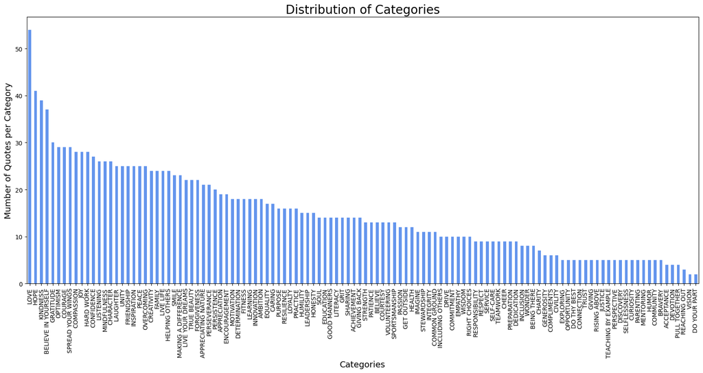

```python
import matplotlib.pyplot as plt
data["Category"].value_counts().plot.bar(figsize=(20,8), color='cornflowerblue')
plt.title('Distribution of Categories', fontsize=20)
plt.xlabel('Categories', fontsize=14)
plt.ylabel('Mumber of Quotes per Category', fontsize=14)
plt.show
```

# Dataset Cleaning 🧹

We want to clean up our data set. This includes lowercasing all characters, encoding of text in UTF-8, and decoding of text as ASCII.

This means that we want to cleanse the data of any unusual characters to be decoded into normal ASCII characters.

```python
def clean_text(txt):
    txt = "".join(v for v in txt).lower()
    txt = txt.encode("utf8").decode("ascii",'ignore')
    return txt

corpus = [clean_text(x) for x in quotes]
corpus[:10]
```

```
['love:let us see what love can do. ',
 'love:we cant heal the world today. but we can begin with a voice of compassion, a heart of love, and an act of kindness. ',
 'listening:listen with curiosity. speak with honesty. act with integrity. ',
 'listening:the most basic and powerful way to connect to another person is to listen. just listen. ',
 'listening:knowledge speaks, but wisdom listens. ',
 'listening:deep listening is the kind of listening that can help relieve the suffering of another person. ',
 'listening:every person in this life has something to teachand as soon as you accept that, you open yourself to truly listening. ',
 'stewardship:there are no problems we cannot solve together, and very few that we can solve by ourselves. ',
 'stewardship:i always wondered why somebody didnt do something about that; then i realized that i am somebody. ',
 'stewardship:let us develop respect for all living things. let us try to replace violence and intolerance with understanding, compassion and love. ']
```

# Generating Sequence of N Combinations of Tokens 🪙

In text generation, we want to predict the next word/token based on the given input sequence of tokens/words.

This leads us to Tokenization of our current input quotes. This is the process of extracting tokens (terms / words) from a corpus (collection of documents). The Tensorflow library has a tokenization model that can be used to obtain the tokens and their index in the corpus. This step allows every entry in the dataset to be converted into sequence of tokens.

```python
tokenizer = Tokenizer(filters='!"#$%&()*+-/:;<=>@[\\]^_`{|}~\t\n',)

def get_sequence_of_tokens(corpus):
    ## tokenization
    new_corpus = []
    for x in corpus:
      to_tokenize = ['.',',',':',';','!','?']
      end_tokenize = [' .',' ,',' :',' ;',' !',' ?']
      for i, v in enumerate(to_tokenize):
        x = x.replace(v, end_tokenize[i])
      new_corpus.append(x)
    corpus = new_corpus

    tokenizer.fit_on_texts(corpus)
    total_words = len(tokenizer.word_index) + 1

    ## convert data to sequence of tokens
    input_sequences = []
    for line in corpus:
        token_list = tokenizer.texts_to_sequences([line])[0]
        for i in range(1, len(token_list)):
            n_gram_sequence = token_list[:i+1]
            input_sequences.append(n_gram_sequence)
    return input_sequences, total_words

inp_sequences, total_words = get_sequence_of_tokens(corpus)
inp_sequences[:10]
```

```
[[27, 113],
 [27, 113, 57],
 [27, 113, 57, 126],
 [27, 113, 57, 126, 21],
 [27, 113, 57, 126, 21, 27],
 [27, 113, 57, 126, 21, 27, 20],
 [27, 113, 57, 126, 21, 27, 20, 24],
 [27, 113, 57, 126, 21, 27, 20, 24, 1],
 [27, 14],
 [27, 14, 389]]
```

# Distribution of Words 📊

The word "kindness" occured quite frequently within the corpus. In our previous graph we saw that the category "LOVE" had a disproportionate amount of quotes. This is a factor as to why a word like "kindness" would also appear fairly frequently within the corpus. 😀

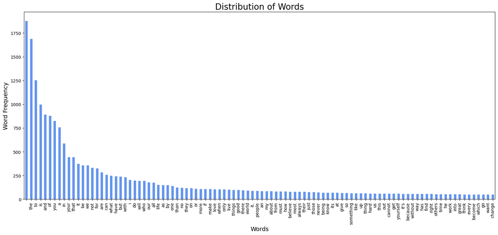

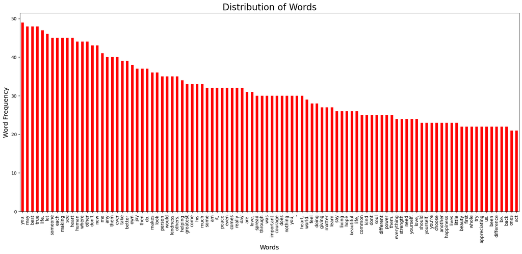

```python
words = []
for sent in corpus:
    splitted = sent.split(" ")
    for word in splitted:
        words.append(word)
mySeries = pd.Series(words)

mySeries.value_counts()[0:100].plot.bar(figsize=(20,8), color='cornflowerblue')
plt.title('Distribution of Words', fontsize=20)
plt.xlabel('Words', fontsize=14)
plt.ylabel('Word Frequency', fontsize=14)
plt.show()

mySeries.value_counts()[100:200].plot.bar(figsize=(20,8), color='red')
plt.title('Distribution of Words', fontsize=20)
plt.xlabel('Words', fontsize=14)
plt.ylabel('Word Frequency', fontsize=14)
plt.show()
```

# 🅿adding, 🅿redictors, and 🅿-Labels

Previously we created a combinations in upto N tokens in our n-gram tokenization step. These combinations all have different lengths and need to be equal before we pass them into our model. To do this, we are going to use the pad_sequence function of Keras within Tensorflow and we will add the padding to the beginning of each sequence. To create the predictors and labels for our model, we use the first N-1 tokens as predictors and the last token as the label.

```python
def generate_padded_sequences(input_sequences):
    max_sequence_len = max([len(x) for x in input_sequences])
    input_sequences = np.array(pad_sequences(input_sequences, maxlen=max_sequence_len, padding='pre'))

    predictors, label = input_sequences[:,:-1],input_sequences[:,-1]
    label = ku.to_categorical(label, num_classes=total_words)
    return predictors, label, max_sequence_len

predictors, label, max_sequence_len = generate_padded_sequences(inp_sequences)
```

# LSTMs and GRUs for Text Generation 🟡 (IFYKYK)

[figure not shown]

In a Recurrent Neural Network the output of a layer is used as the input for the same or lower layer. This creates loops in the neural network architecture, acting as a 'memory state' of the neurons. This state allows the neurons an ability to remember what have been learned so far. In theory an RNN can learn long term memory but in practice it cannot. This means that the idea of a traditional RNN suffers from vanishing gradients. In this problem, while learning with a large number of layers, eventually the gradients may become very small and do not make a significant change when updating the weights for the next layer. To mitigate this issue, LSTMs (Long Short Term Memory) were developed.

Input embedding layer

- When considering natural language processing, this layer allows us to capture and store syntactic similarities

GRU Layer

- LSTMs use an input, forget, and output gates
- GRUs use solely an update and reset layer to accomplish the same feat
- GRUs are less complex making them more effective on smaller datasets like ours
- Tanh activation, but on recursion uses sigmoid
- It uses the gates on the previous hidden state to determine which parts to update and which parts to ignore.

Dropout Layer

- Temporarily deactivates a certain number of neurons, and avoids them during backpropagation
- Used a dropout of 0.5
- Reduces overfitting

Dense Layer

- We use the softmax function
- Fully connects to ensure appropriate output

Compilation

- The model is compiled through categorical cross entropy loss and the ADAM optimizer

[figure not shown]

Sources:

- https://www.tensorflow.org/api_docs/python/tf/keras/layers/GRU
- https://www.superdatascience.com/blogs/recurrent-neural-networks-rnn-the-vanishing-gradient-problem/
- https://medium.com/analytics-vidhya/understanding-embedding-layer-in-keras-bbe3ff1327ce
- https://www.mathworks.com/help/deeplearning/ref/nnet.cnn.layer.grulayer.html

See output for the next code bloxk to see model structure.

```
Model: "sequential"
_________________________________________________________________
 Layer (type)                Output Shape              Param #
=================================================================
 embedding (Embedding)       (None, 136, 512)          1911808

 gru (GRU)                   (None, 512)               1575936

 dropout (Dropout)           (None, 512)               0

 dense (Dense)               (None, 3734)              1915542

=================================================================
Total params: 5,403,286
Trainable params: 5,403,286
Non-trainable params: 0
_________________________________________________________________
```

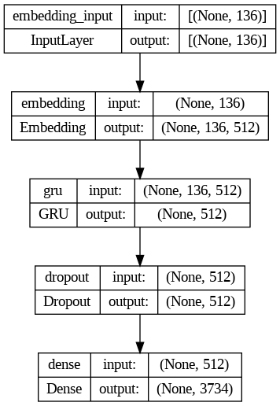

```python
def create_model(max_sequence_len, total_words):
    input_len = max_sequence_len - 1
    model = tf.keras.models.Sequential()

    # Add Input Embedding Layer
    model.add(tf.keras.layers.Embedding(total_words, 512, input_length=input_len))

    # Add Hidden Layer 1 - GRU Layer
    model.add(tf.keras.layers.GRU(512))
    model.add(tf.keras.layers.Dropout(0.5))

    # Add Output Layer
    model.add(Dense(total_words, activation='softmax'))

    model.compile(loss='categorical_crossentropy', optimizer='adam', metrics=['accuracy'])

    return model

model = create_model(max_sequence_len, total_words)
model.summary()
dot_img_file = './model_1.png'
tf.keras.utils.plot_model(model, to_file=dot_img_file, show_shapes=True)
```

# Lets train our model now 🚆

How did we train the model?

- We use a callback monitoring the loss that will stop the training after 3 epochs if the loss does not improve (stops training if the loss starts increasing)
- We train the model over 25 epochs
- We left shuffle=True in our model.fit to reduce bias (random starting point)

Overfitting

- When we trained for 100 epochs, it overfit the data. In our case, this meant it generated sequences of random words that happened to appear frequently in the training data

```python
callback = [EarlyStopping(monitor='loss', patience=3)]
model.fit(predictors, label, epochs=25, callbacks=callback)
```

```
<keras.callbacks.History at 0x7f6296b8ca60>
```

# Generating the text 🖊

We are going to generate text by sequentially predicting the next word following the given input text. We first tokenize the input text, pad the tokenized sequences and then pass that into the trained model to get predicted word. Our final output is our predicted words strung together. We do this until a punctuation is predicted as the next token.

```python
def generate_text(seed_text, model, max_sequence_len):
    output_word = ""
    while output_word != "." and output_word != "!" and output_word != "?":
        token_list = tokenizer.texts_to_sequences([seed_text])[0]
        token_list = pad_sequences([token_list], maxlen=max_sequence_len-1, padding='pre')
        predict_x=model.predict(token_list,verbose=0)
        predicted=np.argmax(predict_x, axis=1)

        output_word = ""
        for word,index in tokenizer.word_index.items():
            if index == predicted:
                output_word = word
                break
        seed_text += " "+output_word
    return seed_text.title()
```

```python
print (generate_text("Is it okay to feel sad?", model, max_sequence_len))
print (generate_text("What is my life's purpose?", model, max_sequence_len))
print (generate_text("What's the meaning of life?", model, max_sequence_len))
print (generate_text("What is my destiny?", model, max_sequence_len))
print (generate_text("Am I loved?", model, max_sequence_len))
print (generate_text("How to be strong?", model, max_sequence_len))
print (generate_text("What can I do?", model, max_sequence_len))
print (generate_text("I am depressed.", model, max_sequence_len))
print (generate_text("How do I help myself?", model, max_sequence_len))
```

```
Is It Okay To Feel Sad? The End Of Your Comfort Zone .
What Is My Life'S Purpose? To Succeed And You Are What We Do .
What'S The Meaning Of Life? Life Is To Find It .
What Is My Destiny? Mission In Life Is To Be Kind , Compassionate , Caring , And Loving In Order To Find And Feel The Deepest Joy Of Life .
Am I Loved? To Be Blessed .
How To Be Strong? A Rainbow In Someone'S Cloud .
What Can I Do? Be Counted What You Can Do .
I Am Depressed. Not Afraid , But I Am About To Me .
How Do I Help Myself? My Soul .
```

## Improvement Ideas 🤔

How can we improve our model in the future?

- We could add more layers to the model (learn more specific features)
- We could fine tune the parameters of our layers in the model (number of  
  nodes, etc.)
- We could experiment more with the number of epochs and the stopping case for the callback function (what it is monitoring and it’s patience)

What are the potential applications of our model?

- Deployment as a webapp so it can reach many people
- An application for people to talk to in order to feel better